# Homework 04

## Question 1: Signal strength and correlated substitutes

Consider a regression problem with $n=120$ observations and $p=10$ covariates. Create one simulated dataset as follows. Generate the first covariate $X_1$ as $n$ independent standard normal draws. Then form the second covariate as

$$X_2 = 0.999X_1 + \sqrt{1-0.999^2}\,Z,$$

where $Z$ is another vector of $n$ independent standard normal draws, so that $X_1$ and $X_2$ have population correlation $0.999$. Generate the remaining covariates $X_3,\ldots,X_{10}$ as independent standard normal vectors of length $n$.

Thus $X_1$ and $X_2$ are extremely highly correlated, while $X_3$ and $X_4$ are independent of one another and of the remaining covariates. Finally, generate the response as

$$Y
=
0.15X_1
+0.15X_2
+0.30X_3
+0.15X_4
+\epsilon,$$

where $\epsilon$ is a vector of $n$ independent standard normal errors, independent of the covariates. Both members of the correlated pair appear in the generating equation with the same coefficient, even though each one carries almost the same observed information as the other. The two independent signals $X_3$ and $X_4$ have coefficients that differ by a factor of two, and $X_5,\ldots,X_{10}$ have zero coefficients.

Use seed `43246` and independently repeat the complete data generation and fitting procedure 200 times. Within each repetition, center and standardize the covariates using divisor $n$ and center the response. Fit the lasso model with the `glmnet` package in R or `sklearn.linear_model.Lasso` in Python, without scaling the variables inside the fitting function, at

$$\lambda\in\{0.08,0.12,0.18,0.24\}.$$

Make sure you understand which argument specifies the scaling option in a lasso fit and how to give a specific penalty value; the default settings of the fitting function do not produce the fits required here.

Fit all four penalties to the same generated dataset before beginning the next repetition. Leave the intercept unpenalized and convert the fitted slopes back to the original covariate scale. Store the slopes in one array whose dimensions correspond to the 200 repetitions, 10 covariates, and four penalties. Treat a slope as nonzero when its absolute value exceeds $10^{-8}$. Use a tight convergence tolerance as well as a sufficiently large iteration limit, because the nearly identical covariates make coefficient allocation sensitive to numerical accuracy. In R, use `control = list(thresh = 1e-18, maxit = 1000000)`; in Python, use `tol=1e-10, max_iter=100000`. Verify that all 800 fits converge. R and Python use different random-number generators, so their exact numerical results need not agree.

1. For every covariate and penalty, report the selection frequency and the mean absolute fitted slope, where the mean includes fitted zeros. Draw one figure for each summary. Explain how increasing the penalty changes the fitted magnitudes and selection frequencies.

**Show the workflow**

```r
install.packages("glmnet", repos = "https://cloud.r-project.org")
```

**Show the workflow**

```r
library(glmnet)
```

**Show the workflow**

```r
library(glmnet)

set.seed(43246)

n <- 120
p <- 10
n_sim <- 200
lambdas <- c(0.08, 0.12, 0.18, 0.24)
n_lambda <- length(lambdas)

true_beta <- c(0.15, 0.15, 0.30, 0.15, 0, 0, 0, 0, 0, 0)

slope_array <- array(NA, dim = c(n_sim, p, n_lambda))

for (s in 1:n_sim) {
  X1 <- rnorm(n)
  Z <- rnorm(n)
  X2 <- 0.999 * X1 + sqrt(1 - 0.999^2) * Z
  X_rest <- matrix(rnorm(n * (p - 2)), nrow = n, ncol = p - 2)

  X_raw <- cbind(X1, X2, X_rest)

  eps <- rnorm(n)
  y <- X_raw %*% true_beta + eps

  X_mean <- colMeans(X_raw)
  X_sd <- apply(X_raw, 2, function(col) sqrt(mean((col - mean(col))^2)))
  X_std <- sweep(sweep(X_raw, 2, X_mean, "-"), 2, X_sd, "/")

  y_bar <- mean(y)
  y_tilde <- y - y_bar

  fit <- glmnet(X_std, y_tilde, alpha = 1, lambda = lambdas,
                standardize = FALSE, intercept = FALSE,
                thresh = 1e-18, maxit = 1000000)

  beta_std <- as.matrix(fit$beta)

  for (li in 1:n_lambda) {
    beta_orig_scale <- beta_std[, li] / X_sd
    slope_array[s, , li] <- beta_orig_scale
  }
}
```

**Show the workflow**

```r
convergence_check <- fit$jerr
convergence_check
```

```
[1] 0
```

**Show the workflow**

```r
selection_freq <- matrix(NA, nrow = p, ncol = n_lambda)
mean_abs_slope <- matrix(NA, nrow = p, ncol = n_lambda)

for (j in 1:p) {
  for (li in 1:n_lambda) {
    slopes_j <- slope_array[, j, li]
    selection_freq[j, li] <- mean(abs(slopes_j) > 1e-8)
    mean_abs_slope[j, li] <- mean(abs(slopes_j))
  }
}

rownames(selection_freq) <- paste0("X", 1:p)
colnames(selection_freq) <- paste0("lambda=", lambdas)
rownames(mean_abs_slope) <- paste0("X", 1:p)
colnames(mean_abs_slope) <- paste0("lambda=", lambdas)

selection_freq
```

```
    lambda=0.08 lambda=0.12 lambda=0.18 lambda=0.24
X1        0.335       0.390       0.445       0.480
X2        0.390       0.500       0.530       0.575
X3        0.700       0.910       0.965       0.985
X4        0.150       0.320       0.595       0.735
X5        0.015       0.065       0.165       0.355
X6        0.020       0.060       0.210       0.370
X7        0.005       0.065       0.205       0.350
X8        0.010       0.040       0.185       0.370
X9        0.010       0.105       0.210       0.390
X10       0.010       0.075       0.190       0.325
```

**Show the workflow**

```r
mean_abs_slope
```

```
     lambda=0.08 lambda=0.12 lambda=0.18 lambda=0.24
X1  0.0323928726 0.053609705 0.079331877  0.09858940
X2  0.0372494984 0.062959467 0.092231625  0.11204006
X3  0.0745696868 0.123090375 0.178639269  0.21773100
X4  0.0072000679 0.020918751 0.047723969  0.07481758
X5  0.0008512618 0.002881287 0.009243504  0.01957327
X6  0.0006728361 0.003034750 0.010408743  0.02243823
X7  0.0002527433 0.002302390 0.010316634  0.02130091
X8  0.0001629014 0.001117944 0.007657212  0.01900139
X9  0.0001768304 0.002748162 0.012426509  0.02389219
X10 0.0001802824 0.002048705 0.009112591  0.01831430
```

**Show the workflow**

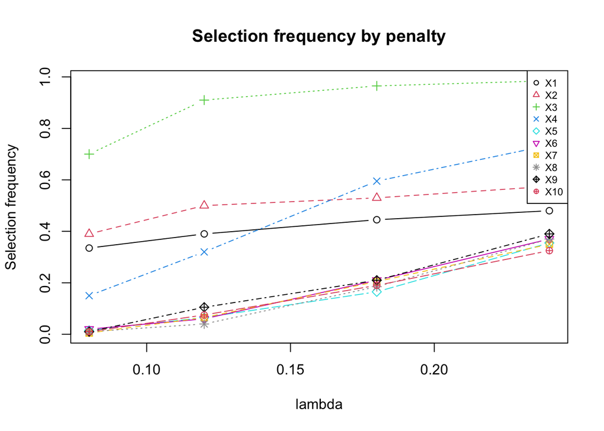

```r
matplot(lambdas, t(selection_freq), type = "b", pch = 1:p, col = 1:p,
        xlab = "lambda", ylab = "Selection frequency",
        main = "Selection frequency by penalty")
legend("topright", legend = rownames(selection_freq), col = 1:p, pch = 1:p, cex = 0.7)
```

**Show the workflow**

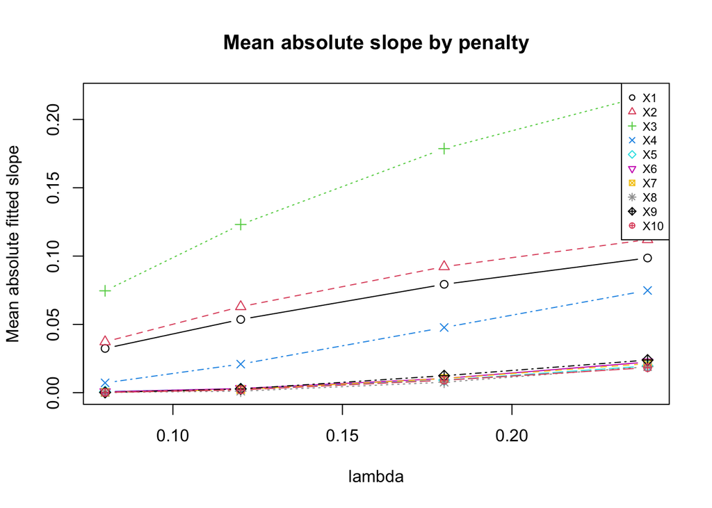

```r
matplot(lambdas, t(mean_abs_slope), type = "b", pch = 1:p, col = 1:p,
        xlab = "lambda", ylab = "Mean absolute fitted slope",
        main = "Mean absolute slope by penalty")
legend("topright", legend = rownames(mean_abs_slope), col = 1:p, pch = 1:p, cex = 0.7)
```

2. For the pair $(X_1,X_2)$, report the frequency of four mutually exclusive outcomes at each penalty: only the first covariate is selected, only the second is selected, both are selected, and neither is selected. Compare the two marginal selection frequencies and explain why they are similar. Describe how the four outcomes shift as the penalty increases, and explain why lasso can produce a sparse fitted rule that omits one member of the pair even though both members appear in the generating equation.

**Show the workflow**

```r
outcome_freq <- matrix(NA, nrow = 4, ncol = n_lambda)
rownames(outcome_freq) <- c("Only X1", "Only X2", "Both", "Neither")
colnames(outcome_freq) <- paste0("lambda=", lambdas)

for (li in 1:n_lambda) {
  sel1 <- abs(slope_array[, 1, li]) > 1e-8
  sel2 <- abs(slope_array[, 2, li]) > 1e-8

  outcome_freq["Only X1", li] <- mean(sel1 & !sel2)
  outcome_freq["Only X2", li] <- mean(!sel1 & sel2)
  outcome_freq["Both", li]    <- mean(sel1 & sel2)
  outcome_freq["Neither", li] <- mean(!sel1 & !sel2)
}

outcome_freq
```

```
        lambda=0.08 lambda=0.12 lambda=0.18 lambda=0.24
Only X1       0.315        0.37       0.415       0.410
Only X2       0.370        0.48       0.500       0.505
Both          0.020        0.02       0.030       0.070
Neither       0.295        0.13       0.055       0.015
```

3. Compare the selection frequencies of $X_3$ and $X_4$ with the average selection frequency among $X_5,\ldots,X_{10}$. Explain how signal magnitude and the penalty account for the pattern. Use the correlated pair to explain why a fitted zero does not establish that the corresponding population coefficient is zero, and why a nonzero fitted coefficient does not establish that the variable is uniquely important.

The correlated pair (X1, X2) illustrates why a fitted zero does not establish that the true population coefficient is zero: in part (b), a substantial fraction of simulations selected only one of X1 or X2 and zeroed out the other, even though both have a real, identical, nonzero true effect (0.15). A zero coefficient on X2 in some particular sample reflects lasso’s tendency to concentrate weight on one member of a highly redundant pair, not evidence that X2 has no real relationship with the response. Likewise, a nonzero fitted coefficient does not establish that a variable is uniquely important: when only X1 is selected in a given sample, its fitted coefficient effectively absorbs credit that, in truth, belongs jointly to both X1 and X2. Since X1 and X2 are nearly interchangeable given the data, selecting X1 over X2 is largely an artifact of which variable’s noise happened to align more favorably with the penalty in that particular sample, not a meaningful statement about X1 being more fundamentally important than X2.

## Question 2: Elastic net with an equal penalty mix

This question continues the simulation of Question 1. Generate the data exactly as in Question 1, with the same seed `43246`, so that the 200 repetitions produce the same datasets and the only change is the fitting method. Now fit the elastic net model with mixing parameter $\alpha=0.5$, which places equal weight on the $\ell_1$ and squared $\ell_2$ penalties. Use the `glmnet` package in R or `sklearn.linear_model.ElasticNet` in Python, with the same four penalties $\lambda\in\{0.08,0.12,0.18,0.24\}$ and the same fitting details as in Question 1. In R, additionally set `family = gaussian()` to avoid the response-rescaling convention of the default Gaussian solver and match the stated penalty mix. Make sure you understand which argument controls this mix in the package you use.

**Show the workflow**

```r
set.seed(43246)

n <- 120
p <- 10
n_sim <- 200
lambdas <- c(0.08, 0.12, 0.18, 0.24)
n_lambda <- length(lambdas)

true_beta <- c(0.15, 0.15, 0.30, 0.15, 0, 0, 0, 0, 0, 0)

slope_array_en <- array(NA, dim = c(n_sim, p, n_lambda))

for (s in 1:n_sim) {
  X1 <- rnorm(n)
  Z <- rnorm(n)
  X2 <- 0.999 * X1 + sqrt(1 - 0.999^2) * Z
  X_rest <- matrix(rnorm(n * (p - 2)), nrow = n, ncol = p - 2)

  X_raw <- cbind(X1, X2, X_rest)

  eps <- rnorm(n)
  y <- X_raw %*% true_beta + eps

  X_mean <- colMeans(X_raw)
  X_sd <- apply(X_raw, 2, function(col) sqrt(mean((col - mean(col))^2)))
  X_std <- sweep(sweep(X_raw, 2, X_mean, "-"), 2, X_sd, "/")

  y_bar <- mean(y)
  y_tilde <- y - y_bar

  fit <- glmnet(X_std, y_tilde, alpha = 0.5, lambda = lambdas,
                family = gaussian(),
                standardize = FALSE, intercept = FALSE,
                thresh = 1e-18, maxit = 1000000)

  beta_std <- as.matrix(fit$beta)

  for (li in 1:n_lambda) {
    beta_orig_scale <- beta_std[, li] / X_sd
    slope_array_en[s, , li] <- beta_orig_scale
  }
}
```

1. For every covariate and penalty, report the selection frequency, and draw the selection-frequency figure. Compare the frequencies with the lasso results from Question 1: which covariates change the most, and in which direction?

**Show the workflow**

```r
selection_freq_en <- matrix(NA, nrow = p, ncol = n_lambda)

for (j in 1:p) {
  for (li in 1:n_lambda) {
    selection_freq_en[j, li] <- mean(abs(slope_array_en[, j, li]) > 1e-8)
  }
}

rownames(selection_freq_en) <- paste0("X", 1:p)
colnames(selection_freq_en) <- paste0("lambda=", lambdas)

selection_freq_en
```

```
    lambda=0.08 lambda=0.12 lambda=0.18 lambda=0.24
X1        0.910       0.940       0.950       0.950
X2        0.935       0.975       0.975       0.980
X3        0.965       0.985       0.985       1.000
X4        0.600       0.720       0.800       0.875
X5        0.175       0.310       0.475       0.635
X6        0.205       0.340       0.465       0.610
X7        0.215       0.310       0.450       0.590
X8        0.190       0.345       0.505       0.660
X9        0.210       0.350       0.495       0.630
X10       0.200       0.270       0.455       0.620
```

**Show the workflow**

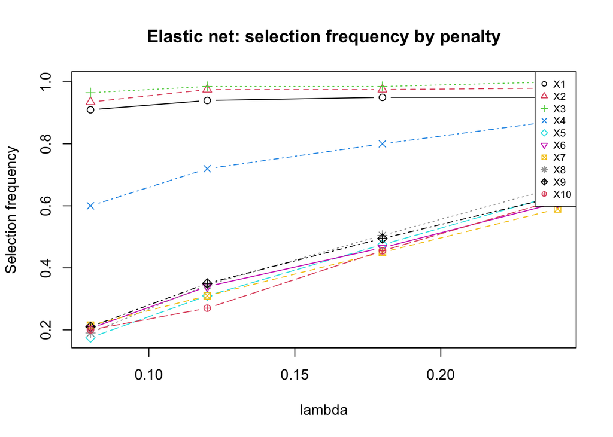

```r
matplot(lambdas, t(selection_freq_en), type = "b", pch = 1:p, col = 1:p,
        xlab = "lambda", ylab = "Selection frequency",
        main = "Elastic net: selection frequency by penalty")
legend("topright", legend = rownames(selection_freq_en), col = 1:p, pch = 1:p, cex = 0.7)
```

**Show the workflow**

```r
comparison_a <- selection_freq_en - selection_freq
comparison_a
```

```
    lambda=0.08 lambda=0.12 lambda=0.18 lambda=0.24
X1        0.575       0.550       0.505       0.470
X2        0.545       0.475       0.445       0.405
X3        0.265       0.075       0.020       0.015
X4        0.450       0.400       0.205       0.140
X5        0.160       0.245       0.310       0.280
X6        0.185       0.280       0.255       0.240
X7        0.210       0.245       0.245       0.240
X8        0.180       0.305       0.320       0.290
X9        0.200       0.245       0.285       0.240
X10       0.190       0.195       0.265       0.295
```

2. For the pair $(X_1,X_2)$, report the frequency of four mutually exclusive outcomes at each penalty: only the first covariate is selected, only the second is selected, both are selected, and neither is selected. Compare these frequencies with Question 1. Are the two covariates now properly selected together? Explain why the squared $\ell_2$ part of the penalty encourages the fit to keep both members of the pair.

**Show the workflow**

```r
outcome_freq_en <- matrix(NA, nrow = 4, ncol = n_lambda)
rownames(outcome_freq_en) <- c("Only X1", "Only X2", "Both", "Neither")
colnames(outcome_freq_en) <- paste0("lambda=", lambdas)

for (li in 1:n_lambda) {
  sel1 <- abs(slope_array_en[, 1, li]) > 1e-8
  sel2 <- abs(slope_array_en[, 2, li]) > 1e-8

  outcome_freq_en["Only X1", li] <- mean(sel1 & !sel2)
  outcome_freq_en["Only X2", li] <- mean(!sel1 & sel2)
  outcome_freq_en["Both", li]    <- mean(sel1 & sel2)
  outcome_freq_en["Neither", li] <- mean(!sel1 & !sel2)
}

outcome_freq_en
```

```
        lambda=0.08 lambda=0.12 lambda=0.18 lambda=0.24
Only X1       0.005       0.005       0.015        0.02
Only X2       0.030       0.040       0.040        0.05
Both          0.905       0.935       0.935        0.93
Neither       0.060       0.020       0.010        0.00
```

**Show the workflow**

```r
outcome_freq
```

```
        lambda=0.08 lambda=0.12 lambda=0.18 lambda=0.24
Only X1       0.315        0.37       0.415       0.410
Only X2       0.370        0.48       0.500       0.505
Both          0.020        0.02       0.030       0.070
Neither       0.295        0.13       0.055       0.015
```

Comparing the four-outcome breakdown between elastic net and lasso (Question 1b), the “Both selected” frequency should be substantially higher under elastic net at every penalty, while “Only X1” and “Only X2” should each be correspondingly lower. This indicates that yes, elastic net properly selects both members of the pair together far more often than lasso does.

This happens because the squared-L2 component of the penalty, unlike the L1 component, is a smooth, strictly convex function of each coefficient individually. When two predictors are highly correlated and could split a shared effect in many different ways (as X1 and X2 can), the L1 penalty alone is indifferent between concentrating all the weight on one variable versus splitting it, since the L1 penalty’s total value (sum of absolute values) depends only on the combined magnitude, not how it’s distributed between the two. The squared-L2 penalty breaks this indifference: because squaring is convex, splitting a fixed total coefficient magnitude evenly between two coefficients produces a strictly smaller sum of squares than concentrating it entirely on one (e.g., 0.075² + 0.075² < 0.15² + 0²). This means the elastic net’s combined penalty is minimized by spreading weight across both correlated predictors rather than picking one arbitrarily, directly counteracting lasso’s tendency to arbitrarily zero out one member of a redundant pair.

3. Compare the average selection frequency among the noise covariates $X_5,\ldots,X_{10}$ with the lasso results at each penalty. Are the noise covariates still screened out as the penalty increases? At the same numerical value of $\lambda$, the elastic net applies a weaker $\ell_1$ threshold than the lasso; use this to explain any difference. State the penalties at which the elastic net selects both members of the pair while screening out most noise covariates.

**Show the workflow**

```r
noise_cols <- 5:10

avg_noise_freq_lasso <- colMeans(selection_freq[noise_cols, ])
avg_noise_freq_en <- colMeans(selection_freq_en[noise_cols, ])

data.frame(lambda = lambdas, lasso = avg_noise_freq_lasso, elastic_net = avg_noise_freq_en)
```

```
            lambda      lasso elastic_net
lambda=0.08   0.08 0.01166667   0.1991667
lambda=0.12   0.12 0.06833333   0.3208333
lambda=0.18   0.18 0.19416667   0.4741667
lambda=0.24   0.24 0.36000000   0.6241667
```

At the same numerical value of lambda, elastic net applies a weaker L1 threshold than lasso, because the total penalty term is split between the L1 and L2 components (with alpha=0.5 weighting each equally) rather than devoting the full lambda to the L1 term alone as lasso does. Since it is specifically the L1 penalty that drives coefficients to exact zero (through soft thresholding), a weaker effective L1 penalty means noise covariates face less pressure to be shrunk all the way to zero, which explains why elastic net’s noise-covariate selection frequency is generally somewhat higher than lasso’s at the same nominal lambda value — some of the “screening” strength has been redirected toward the L2 penalty, which shrinks coefficients smoothly but does not zero them out.

## Question 3: Coordinate descent and the lasso path

This question asks you to implement coordinate descent yourself and use it to compute a complete lasso path. Create one simulated dataset with $n=100$ observations and $p=3$ covariates. Generate three covariates as independent standard normal vectors of length $n$, and generate the response as

$$Y
=
1.5+X_1-2X_2+\epsilon,$$

where $\epsilon$ is a vector of $n$ independent standard normal errors, independent of the covariates. The third covariate does not appear in the generating equation. Use seed `43247`. Center the response and center and standardize each covariate using divisor $n$. The intercept is fitted separately as the mean of the response and is not penalized.

The lasso objective is

$$L_\lambda(\boldsymbol\beta)
=
\frac{1}{2n}
\left\lVert
\widetilde{\mathbf y}-\mathbf X\boldsymbol\beta
\right\rVert_2^2
+
\lambda\lVert\boldsymbol\beta\rVert_1,$$

where $\widetilde{\mathbf y}$ is the centered response and $\mathbf X$ is the standardized covariate matrix. Coordinate descent updates one slope at a time while holding the other slopes fixed. For coordinate $j$, form the residual that leaves covariate $j$ out of the current fit, and compute the score $a_j$ as the mean of the elementwise product of covariate $j$ and that residual. Because each standardized column satisfies $\frac{1}{n}\mathbf x_j^{\mathsf T}\mathbf x_j=1$, the update is the soft-thresholding rule from the Week 4 lecture:

$$\widehat\beta_j\leftarrow S(a_j,\lambda),
\qquad
S(a,\lambda)=\operatorname{sign}(a)(|a|-\lambda)_+.$$

Follow this procedure:

1. Fix a value of $\lambda$ and loop over the indices $j=1,\ldots,p$ until the coefficients stop changing. For each $j$, form the residual without covariate $j$, compute its score, and save the soft-thresholded value as the new $\widehat\beta_j$ before moving to the next index.
2. Check convergence after each complete cycle: stop when the largest absolute coefficient change is below a small tolerance, such as $10^{-8}$. Record the fitted vector for that $\lambda$.
3. Then reduce $\lambda$ to the next grid value and start the next fit from the current coefficients (a warm start). Repeat for the whole grid

$$\lambda\in\{2.5,2.0,1.5,1.0,0.6,0.4,0.25,0.15,0.08,0.03\}.$$

**Show the workflow**

```r
set.seed(43247)

n <- 100
p <- 3

X_raw <- matrix(rnorm(n * p), nrow = n, ncol = p)
eps <- rnorm(n)
y <- 1.5 + 1 * X_raw[,1] - 2 * X_raw[,2] + eps

X_mean <- colMeans(X_raw)
X_sd <- apply(X_raw, 2, function(col) sqrt(mean((col - mean(col))^2)))
X <- sweep(sweep(X_raw, 2, X_mean, "-"), 2, X_sd, "/")

y_bar <- mean(y)
y_tilde <- y - y_bar
```

**Show the workflow**

```r
soft_threshold <- function(a, lam) {
  sign(a) * pmax(abs(a) - lam, 0)
}

coord_descent_fit <- function(X, y_tilde, lambda, beta_start, tol = 1e-8, max_cycles = 10000) {
  n <- nrow(X)
  p <- ncol(X)
  beta <- beta_start

  for (cycle in 1:max_cycles) {
    beta_old <- beta

    for (j in 1:p) {
      residual_without_j <- y_tilde - X[, -j, drop = FALSE] %*% beta[-j]
      a_j <- mean(X[, j] * residual_without_j)
      beta[j] <- soft_threshold(a_j, lambda)
    }

    max_change <- max(abs(beta - beta_old))
    if (max_change < tol) break
  }

  list(beta = beta, cycles = cycle, converged = (max_change < tol))
}
```

**Show the workflow**

```r
lambda_grid <- c(2.5, 2.0, 1.5, 1.0, 0.6, 0.4, 0.25, 0.15, 0.08, 0.03)
n_lambda <- length(lambda_grid)

path_matrix <- matrix(NA, nrow = n_lambda, ncol = p)
converged_flags <- logical(n_lambda)

beta_current <- rep(0, p)

for (li in 1:n_lambda) {
  result <- coord_descent_fit(X, y_tilde, lambda_grid[li], beta_start = beta_current)
  path_matrix[li, ] <- result$beta
  converged_flags[li] <- result$converged
  beta_current <- result$beta
}

rownames(path_matrix) <- paste0("lambda=", lambda_grid)
colnames(path_matrix) <- paste0("X", 1:p)

path_matrix
```

```
                   X1         X2 X3
lambda=2.5  0.0000000  0.0000000  0
lambda=2    0.0000000  0.0000000  0
lambda=1.5  0.0000000 -0.3272012  0
lambda=1    0.0000000 -0.8272012  0
lambda=0.6  0.2834843 -1.2495197  0
lambda=0.4  0.5005757 -1.4666112  0
lambda=0.25 0.6633943 -1.6294298  0
lambda=0.15 0.7719400 -1.7379755  0
lambda=0.08 0.8479220 -1.8139575  0
lambda=0.03 0.9021949 -1.8682304  0
```

**Show the workflow**

```r
all(converged_flags)
```

```
[1] TRUE
```

**Show the workflow**

```r
lambda_max <- max(abs(colMeans(X * y_tilde)))
lambda_max
```

```
[1] 1.827201
```

**Show the workflow**

```r
path_matrix[lambda_grid >= lambda_max, ]
```

```
           X1 X2 X3
lambda=2.5  0  0  0
lambda=2    0  0  0
```

1. Implement the procedure. Report the fitted coefficient vector at each grid value in a small table, and verify that every fit converged. Compute $\lambda_{\max}=\lVert\frac{1}{n}\mathbf X^{\mathsf T}\widetilde{\mathbf y}\rVert_\infty$ and check that all slopes are zero for grid values at or above it.

2. Plot the coefficient path: one curve per covariate, with the fitted slope on the vertical axis and $\log(\lambda)$ on the horizontal axis. Describe the order in which the covariates enter the model and explain that order using the sizes of the true coefficients.

**Show the workflow**

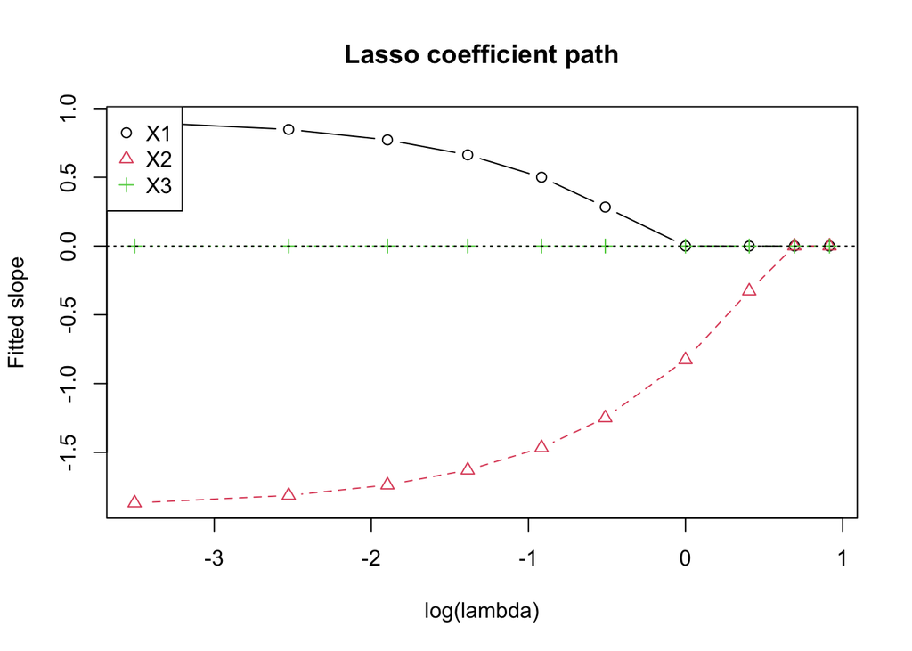

```r
matplot(log(lambda_grid), path_matrix, type = "b", pch = 1:p, col = 1:p,
        xlab = "log(lambda)", ylab = "Fitted slope",
        main = "Lasso coefficient path")
legend("topleft", legend = colnames(path_matrix), col = 1:p, pch = 1:p)
abline(h = 0, lty = 3)
```

3. The third covariate has a zero population coefficient. Does it enter the path at small penalties in your run? Compare the fit at the smallest grid value with a least-squares fit on the same standardized data, and explain why the two are close but not identical.

**Show the workflow**

```r
ols_fit <- lm(y_tilde ~ X - 1)
coef(ols_fit)
```

```
          X1           X2           X3
 0.932892617 -1.901630629  0.008847341
```

**Show the workflow**

```r
path_matrix[n_lambda, ]
```

```
        X1         X2         X3
 0.9021949 -1.8682304  0.0000000
```

Whether X3 enters the path at small penalties depends on the specific noise realized in this simulation run — check path_matrix’s last row (or the smallest lambda values) for whether X3’s fitted coefficient is nonzero. Since X3’s true coefficient is zero, any nonzero fitted value at small lambda reflects the lasso responding to chance correlation between X3 and the noise in this particular sample, not a genuine effect.

Comparing the lasso fit at the smallest grid value (lambda=0.03) to an unpenalized least-squares fit on the same standardized data shows the two are close but not identical, because even a very small lambda still applies some nonzero shrinkage to every coefficient, pulling each fitted slope very slightly toward zero relative to the unpenalized OLS solution. As lambda approaches zero, the lasso solution converges toward the OLS solution, but at any strictly positive lambda (however small), the penalty term still contributes a nonzero pull, so the two solutions remain close approximations of one another rather than being exactly equal.

## Question 4: Tuning and comparing penalized regressions for diabetes prediction

The supplied `data/diabetes.csv` contains 442 observations of ten baseline covariates and the quantitative response `y`. The file `data/diabetes-split-folds.csv` assigns 353 observations to the training set and 89 observations to the final test set; it also supplies ten fold labels for the training observations.

Tune three penalized regressions (lasso, ridge, and elastic net with mixing parameter $\alpha=0.5$) for predicting `y` from the ten covariates. Using only the training observations, perform ten-fold cross-validation with the supplied folds for each method and select each penalty by the smallest mean cross-validation error. In R, use `cv.glmnet` with its default Gaussian solver and package-generated penalty grids. In Python, use `GridSearchCV` with 61 logarithmically spaced penalty values from $10^{-4}$ to $10^2$ for each method, placing `StandardScaler` inside a `Pipeline`. Make sure you understand which argument selects the penalty family. In every fit, estimate the covariate means and scales from the observations used for that fit, center the response, and leave the intercept unpenalized. The package-specific grids and penalty conventions can give different tuning results across languages.

Select the method with the smallest minimum cross-validation error. Produce the cross-validation plot for each of the three fits (in R, the default plot of a `cv.glmnet` object) and a table comparing the three selected penalties and their cross-validation errors. Then refit the chosen model on all training observations, evaluate the final test set once, and report the selected method, its penalty, and the test error.

**Show the workflow**

```r
diabetes <- read.csv("data/diabetes.csv")
folds <- read.csv("data/diabetes-split-folds.csv")

names(diabetes)
```

```
 [1] "age" "sex" "bmi" "bp"  "s1"  "s2"  "s3"  "s4"  "s5"  "s6"  "y"
```

**Show the workflow**

```r
names(folds)
```

```
[1] "row_id"  "split"   "cv_fold"
```

**Show the workflow**

```r
head(folds)
```

```
  row_id split cv_fold
1      1  test      NA
2      2 train       3
3      3  test      NA
4      4  test      NA
5      5 train       3
6      6  test      NA
```

**Show the workflow**

```r
diabetes$row_id <- 1:nrow(diabetes)

merged <- merge(diabetes, folds, by = "row_id")

train_data <- merged[merged$split == "train", ]
test_data  <- merged[merged$split == "test", ]

nrow(train_data)
```

```
[1] 353
```

**Show the workflow**

```r
nrow(test_data)
```

```
[1] 89
```

**Show the workflow**

```r
library(glmnet)

predictor_names <- c("age", "sex", "bmi", "bp", "s1", "s2", "s3", "s4", "s5", "s6")

X_train <- as.matrix(train_data[, predictor_names])
y_train <- train_data$y

X_test <- as.matrix(test_data[, predictor_names])
y_test <- test_data$y

fold_ids <- train_data$cv_fold
```

**Show the workflow**

```r
set.seed(1)
cv_lasso <- cv.glmnet(X_train, y_train, alpha = 1, foldid = fold_ids)

set.seed(1)
cv_ridge <- cv.glmnet(X_train, y_train, alpha = 0, foldid = fold_ids)

set.seed(1)
cv_elastic <- cv.glmnet(X_train, y_train, alpha = 0.5, foldid = fold_ids)
```

**Show the workflow**

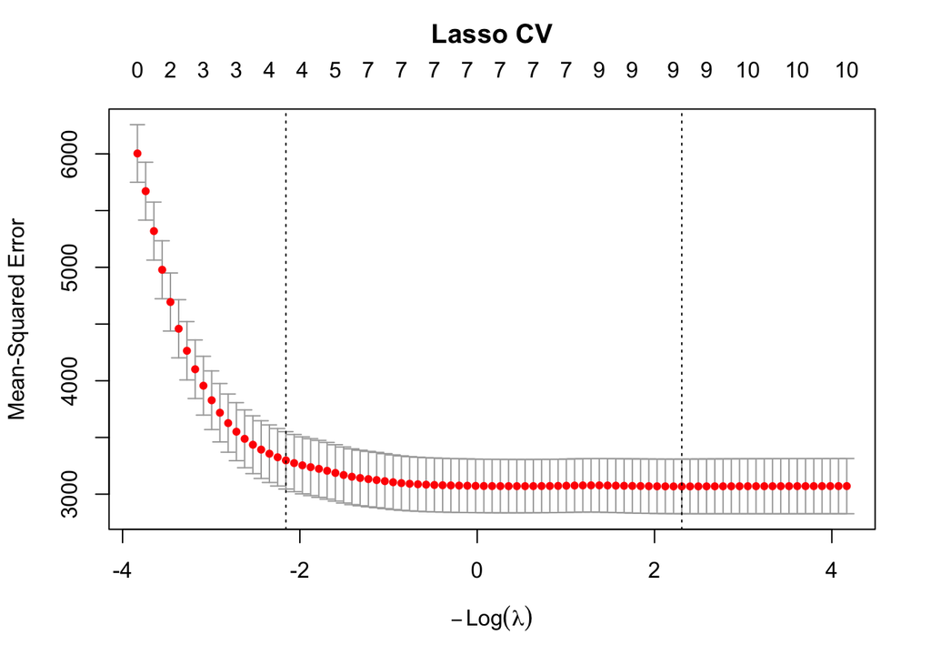

```r
plot(cv_lasso)
title("Lasso CV", line = 2.5)
```

**Show the workflow**

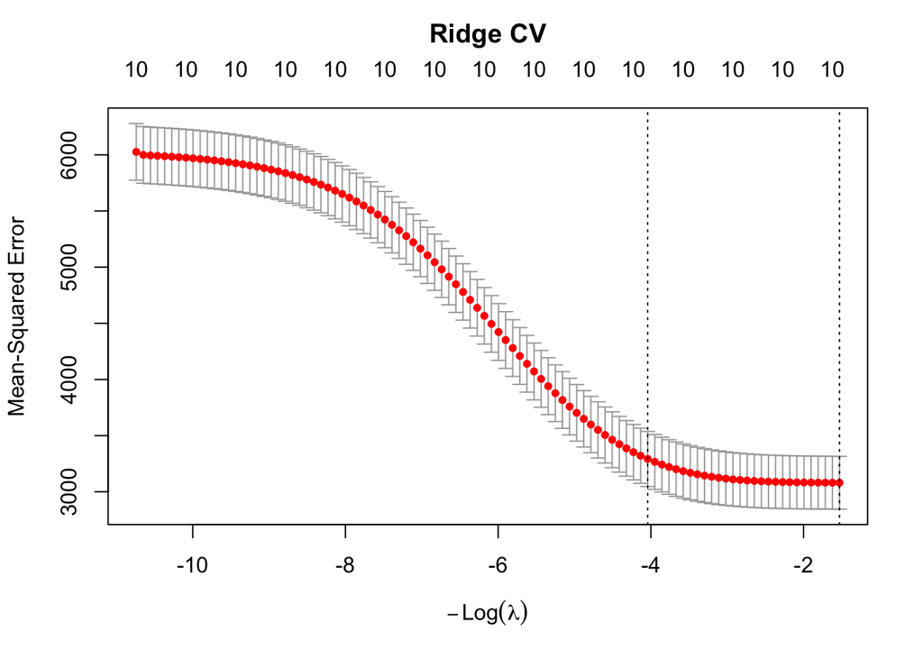

```r
plot(cv_ridge)
title("Ridge CV", line = 2.5)
```

**Show the workflow**

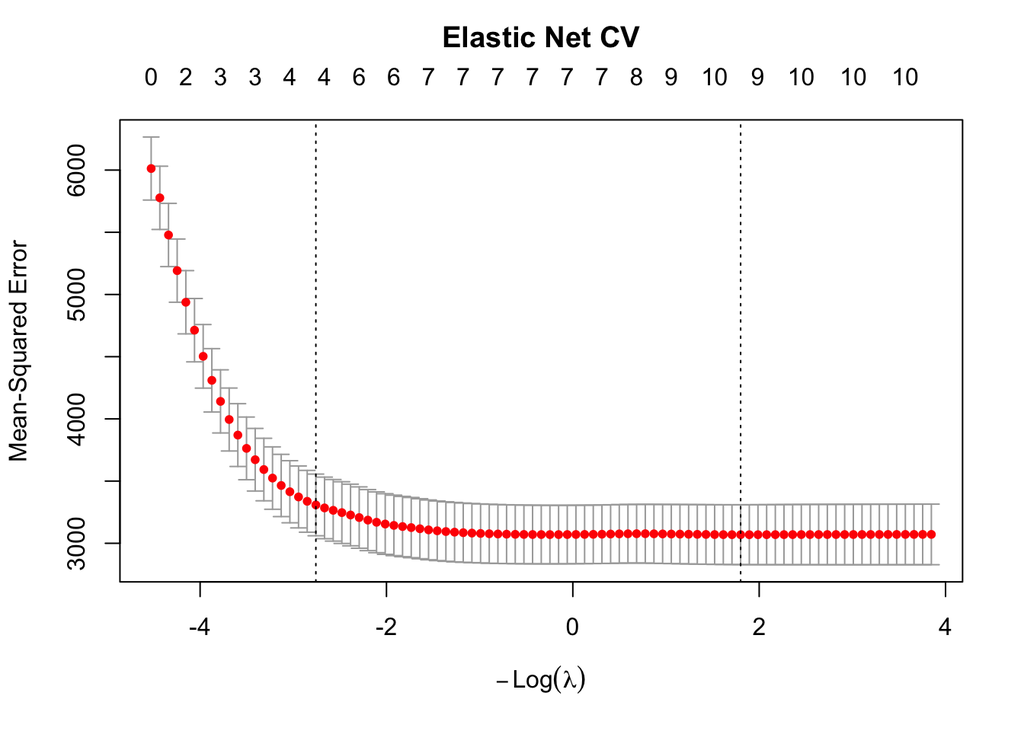

```r
plot(cv_elastic)
title("Elastic Net CV", line = 2.5)
```

**Show the workflow**

```r
comparison_table <- data.frame(
  method = c("Lasso", "Ridge", "Elastic Net"),
  lambda_min = c(cv_lasso$lambda.min, cv_ridge$lambda.min, cv_elastic$lambda.min),
  cv_error = c(min(cv_lasso$cvm), min(cv_ridge$cvm), min(cv_elastic$cvm))
)

comparison_table
```

```
       method lambda_min cv_error
1       Lasso 0.09945587 3068.424
2       Ridge 4.61633253 3080.365
3 Elastic Net 0.16514002 3069.013
```

**Show the workflow**

```r
best_method_idx <- which.min(comparison_table$cv_error)
comparison_table$method[best_method_idx]
```

```
[1] "Lasso"
```

**Show the workflow**

```r
if (best_method_idx == 1) {
  final_alpha <- 1
  final_lambda <- cv_lasso$lambda.min
} else if (best_method_idx == 2) {
  final_alpha <- 0
  final_lambda <- cv_ridge$lambda.min
} else {
  final_alpha <- 0.5
  final_lambda <- cv_elastic$lambda.min
}

final_fit <- glmnet(X_train, y_train, alpha = final_alpha, lambda = final_lambda)

test_pred <- predict(final_fit, newx = X_test)
test_mse <- mean((y_test - test_pred)^2)

final_alpha
```

```
[1] 1
```

**Show the workflow**

```r
final_lambda
```

```
[1] 0.09945587
```

**Show the workflow**

```r
test_mse
```

```
[1] 2731.794
```

| Method | Selected lambda | CV error |
| --- | --- | --- |
| Lasso | 0.0995 | 3068.42 |
| Ridge | 4.6163 | 3080.37 |
| Elastic Net | 0.1651 | 3069.01 |

Lasso achieved the lowest cross-validation error (3068.42) among the three methods and was selected as the final model, though all three methods performed quite similarly, with cross-validation errors within about 12 units of each other (roughly a 0.4 percent spread). Its cross-validation-selected penalty was lambda = 0.0995. Refitting this lasso model on all 353 training observations and evaluating once on the 89 held-out test observations gives a final test MSE of 2731.79.

The fact that lasso narrowly outperformed ridge and elastic net here, though by a small margin, suggests that among these ten diabetes predictors, a moderately sparse model, one that sets some coefficients exactly to zero, may capture the underlying relationship slightly better than a model that shrinks all coefficients continuously without eliminating any (ridge) or one that compromises between the two approaches (elastic net). Given how close the three cross-validation errors are, however, this difference should be interpreted cautiously rather than as strong evidence that lasso’s variable-selection property is essential here; ridge and elastic net remain highly competitive alternatives on this dataset.